# Example of a classification using CMAP

Mariane S. Reis

2023-10-09

## Before starting…

In CMAP, we aim to classify the trajectory $s=\{\omega^{k_1}_{1},..., \omega^{k_t}_{t},...,\omega^{k_T}_{T}\}$. Here:

$T$ is the length of the time sequence;

$\omega^{k_t}_{t} \in \Omega_t = \{\omega^{k_1}_t, ..., \omega^{k_t}_{t},... \omega^{K_t}_{t} \}$;

$\omega^{k_t}_t$ is the actual class at time position $t$ of $s$;

$k_t$ is the indicator of the class in the set $\Omega_t$ that holds the $K_t$ possible classes on time $t$;

$s\in \boldsymbol{\Omega} =\Omega_1 \otimes ... \otimes \Omega_t \otimes ... \otimes \Omega_T$;

$\otimes$ is the Cartesian Product of sets;

$\vec{X} = \{\vec{x_1},..., \vec{x_t},...,\vec{x_T}\}$ is a given observation vector that contains the $T$ temporal observations that can indicate the trajectory composition (e.g., the digital numbers in correspondent pixels in {a given set of images $\boldsymbol{X}$), and $\vec{X} \in \boldsymbol{X}$}.

Here, we suppose that:

$\hat{s} = \arg_s \max (P(\vec{X}|s) \times P(s), s \in \boldsymbol{\Omega}, \vec{X} \in \boldsymbol{X})$

$P(\vec{X}|s) = P(\vec{x_1}|\omega^{k_1}_{1}) \times ...\times P(\vec{x_t}|\omega^{k_t}_{t}) \times ... \times P(\vec{x_T}|\omega^{k_T}_{T})$, as it supposes that the observations are independent in time and that each one depends only on the observed object;

$P(s)$ is the *a priori* probability of a trajectory $s$.

## This example

This example aims to classify a short remote sensing time-series into a land cover classification time series. We will classify three images from different sensors (ALOS/PALSAR, Landsat 5/TM, and EO-1/ALI) and dates (2008, 2010, and 2013). We will also consider different legends for each date. Note that, although we will classify the same image used to train the classifier, the algorithm performs the training and classification processes independently, which allows for the use of samples collected in images from sites/dates that differ to the one being classified (if the targets behave the same in both the attribute spaces, e.g. cross-calibrated data set, same number of channels, same legend/targets).

We will consider that you have installed a suitable version of R and the package “terra”. This example also considers the use of the “Input_dataset” and the R codes “MainFunctions.R” and “AuxiliaryFunctions.R”. We further consider that the working directory is set to a folder containing these data.

First,load the necessary package and the R codes:

```r
# Load the R package
library(terra)

#Load the codes
source("MainFunctions.R")
source("AuxiliaryFunctions.R")
```

The first step to CMAP we will cover is to calculate the probability of the observations given the classes ($P(\vec{x_t}|\omega^{k_t}_{t})$). This will be done independently for each image to be classified.

Let us start with the data set for 2008. In this example, the base image (from which we collect the digital numbers to train the classifier) is a multi-layer tif file in which each layer represents a polarization/band of an image. The labeled samples (indicate the class of selected pixels) are depicted in a raster file of same extent, number of lines/columns, pixel size, and projection than the base image. The pixels are either labeled as the index of a land cover class or as zero (pixels not selected as samples). All labeled pixels will be used to calculate the probability of observation given the class.

(The user is, of course, welcome to use other data format and sampling approaches with the due caution to respect the input format of the main functions.)

Our aim here is to construct a matrix in which each line represents a labeled sample. The first column carries an unique index for each class/sub-class. This is necessary if the user wants to use more than one base image for each training but consider samples of the same class collected in both images independently (e.g., index 1 for class1 samples from base image 1 and index 2 for for class1 samples from image base 2). The second column carries the original label for each class, and the following columns carry the observation values. If you are using only one base image, column 1 will be replicated in column 2. With the example data set (“Input_dataset”), this can be done using the function ‘Construct_Training’. This function uses vectors containing the path to the base images and labeled samples as input.

```r
#Indicate the path of the base image from 2008 to the variable "base"
base<-c("Input_dataset/1_Time_series/Image_2008.tif")

#Indicate the path of the labeled samples from 2008 to the variable "samples"
samples<-c("Input_dataset/2_Labeled_samples/samples_2008.tif")

#Apply the function that constructs the necessary matrix
t.2008<-Construct_Training(base, samples)


#Does the same for the subsequent years
base<-c("Input_dataset/1_Time_series/Image_2010.tif")
samples<-c("Input_dataset/2_Labeled_samples/samples_2010.tif")

t.2010<-Construct_Training(base, samples)


base<-c("Input_dataset/1_Time_series/Image_2013.tif")
samples<-c("Input_dataset/2_Labeled_samples/samples_2013.tif")

t.2013<-Construct_Training(base, samples)
```

Please note that we constructed all the training sets in the same step for exemplification. It is possible to execute this step one date at a time, as at this point we will not use these data sets jointly. Also, we are using a training set for each date because of the use of images from different sensors. The user is welcome to modify the code to suit their needs, such as using only one training set for the classification of all calibrated images.

Once we have the adequate training set, we can calculate the probabilities of observations given each class. This can be done using the Main Function “Probability_observation”. This function uses the previously calculated training data set, a set of observations that indicate the class at a given time, i.e. one of the images of the time-series, and a mask depicting eventual areas not to be included in the analysis. This mask is a raster of one layer, with the same extent, pixel size, and projection of the image. Areas to be included should present a zero value. Pixel with any other value are considered as masked areas. If a mask isn’t included, the algorithm computes the probabilities of the whole image.

In the current version, the function assumes that the data follows a Gaussian distribution:

$P(\vec{x_t}|\omega^{k_t}_{t}) = \int (2\pi)^{-B/2}|\Sigma_{k_t}|^{- 1/2} \times \exp{\{-1/2(\vec{x_t}-m_{k_t})^\intercal \Sigma_{k_t}^{-1}(\vec{x_t}-m_{k_t})\}} d\vec{x_t}$, in which:

$B$ is the number of observed variables (like the channels of the image) of the time $t$;

$m_{k_t}$ is mean vector of the class $\omega^{k_t}_{t}$;

$\Sigma_{k_t}$ is covariance matrix of the class $\omega^{k_t}_{t}$;

$|\cdot|$ is the determinant function;

$\intercal$ is the transpose function.

```r
#Read the image to be classified
img.2008<-rast("Input_dataset/1_Time_series/Image_2008.tif")

#calculates the probabilities of the observations given each class. Here, each layer presents the probabiliry of one class, in the same order as the indexes on the labeled samples.
probs.2008<-Probability_observation(t.2008, img.2008)

#Doing the same for the other dates
img.2010<-rast("Input_dataset/1_Time_series/Image_2010.tif")
probs.2010<-Probability_observation(t.2010, img.2010)


img.2013<-rast("Input_dataset/1_Time_series/Image_2013.tif")
probs.2013<-Probability_observation(t.2013, img.2013)
```

Each set of probabilities is a raster file that can be saved locally and uploaded when needed. They can also be used to classify each date using the Maximum Likelihood Classifier (MLC). MLC results can be obtained using the function “MLC” within the Auxiliary Functions:

```r
#Generating a Maximum Likelihood Classification
ML.2008<-MLC(probs.2008)
```

Once all independent probabilities of the observations given the classes are calculated, we solved the first half of CMAP equation. The missing element is the *a priori* probability of the trajectories $P(s)$. In this example, we will compute these probabilities considering that all trajectories that have only valid transitions receive the same probability value, where the ones with ate least one invalid transitions receive zero. Note that since all values are the same, they could be any value, as it do not interfere with the maximum argument. An easy computational way to do this is to derive transition probabilities matrices for each two consecutive dates in which valid transitions are valued as one (1) and the invalid ones are zero (0). Examples of these can be uploaded from the provided example data set.

The multiplication of matrices can be done using the auxiliary function “Traj_probs”, which uses the paths of the matrices files as input (these must be given in the correct sequence):

```r
#Calculating the values of the a priori probability of each possibel trajectory
Ps<-Traj_probs(c("Input_dataset/3_Matrices/2008-2010.txt",
                 "Input_dataset/3_Matrices/2010-2013.txt"))
```

The result is a matrix containing the classes at each time in each initial column, and the *a priori* probability of that transition in the last column. For convenience, we removed trajectories with probabilities equal to zero within the function.

Now, we have all the necessary elements to proceed to the CMAP classification.

Here we recommend an additional step that may be necessary to your data or not. As CMAP considers the multiplication of many probabilities, which can be a very small number, there is a chance that this operation will reach the computational zero in R for long time series. Although very rare, ir is also possible that all values of probabilities of observations given the class reach zero, hindering the calculation of a maximum. To fix these issues, we recommend using the auxiliary functions “Norm_probs” and “Verify_nulls”. Both functions uses the outputs of the “Probability_observation” function.

```r
#Normalizing values to avoid reaching the computational zero for the 2008 data
probs.n.2008<-Norm_probs(probs.2008)

#Creating a mask for the 2008 dataset
Mask.2008<-Verify_nulls(probs.n.2008)

#Repeating for all dates

probs.n.2010<-Norm_probs(probs.2010)
Mask.2010<-Verify_nulls(probs.n.2010)


probs.n.2013<-Norm_probs(probs.2013)
Mask.2013<-Verify_nulls(probs.n.2013)
```

CMAP itself can be calculated using the main functions “CMAP_memory” or “CMAP_saved”. These functions generate the same results but with slightly different coding approaches. “CMAP_memory”, as the name suggests, operates fully in R memory. “CMAP_saved”, on the other hand, will read files saved in an external folder and save CMAP results in said folder. This last approach was though as a solution to memory problems (other solutions are appreciated).

For the first approach we will use “CMAP_memory”. The input for this function is a list in which each position is one set of probabilities of the observations given the classes of one date (*probs.list*), the *a priori* probabilities of the trajectories (*Ps*), and, optionally, a given mask to define areas not to be classified (*mask*, the function supposes a default one in which all pixels are classified). So:

```r
#Creating the list with the probabilities of observations given the classes. Each position holds the probabilities calculated for one date (in order).
probs.list<-list(probs.n.2008, probs.n.2010, probs.n.2013)

#Creating a single layer raster with the Mask calculated in the previous step.
Mask<-Mask.2008+Mask.2010+Mask.2013

# Calculates the results of the CMAP classification. Each layer is the land cover classification for one date, in the same order as the one provided in the input list. If a mask is provided, masked areas receive zero.

#In this case, we will
CMAP.r<-CMAP_memory (probs.list=probs.list, Ps=Ps, mask=Mask)
```

You can export this result using the “writeRaster” function of the “terra” package as you would any other raster. For documents in tif:

```r
#Exporting results
writeRaster(CMAP.r, "CMAP.tif")
```

Now let us consider you prefer to do this process reading files saved in an external folder, so you can free the memory used in R or process each step at a time for some reason. First, you need to save the previously calculated elements of CMAP in said folder. Here we are saving them in the directory.

```r
#Exporting results of probabilities of observation for each class
writeRaster(probs.n.2008, "probs_n_2008.tif")
writeRaster(probs.n.2010, "probs_n_2010.tif")
writeRaster(probs.n.2013, "probs_n_2013.tif")
```

In the function “CMAP_saved” receives a set of paths for these rasters instead of the raster themselves (*probs.path*), the *a priori* probabilities of each trajectory (*Ps*), a prefix for the file name of all results (*prefix*), and, optionally, the aforementioned mask (mask) and a suffix vector to identify each land cover classification result (*suffix*, if not set, the function will set it from 1 to the number of dates). In this case we will set the suffix as the year of each image but make the calculation without the mask.

```r
#Creates a list of paths to read the rasters
probs.path<-c("probs_n_2008.tif","probs_n_2010.tif","probs_n_2013.tif")

# Calculates the results of the CMAP classification. The results are saved as land cover classifications of each year in the set external folder.
CMAP_saved(probs.path=probs.path, Ps=Ps, prefix="CMAP",suffix=c(2008, 2010, 2013))
```

Now you have the classification done using CMAP! To illustrate the potential of CMAP, see the results of CMAP *vs* the traditional MLC for a given land cover classification result. Specifically, let us see the ones generated for the year 2008 and ALOS/PALSAR data (in which 1 = Bare Soil, 2 = Agriculture, 3 = Pasture, 4 = Secondary vegetation, and 5 = Forest). Note that CMAP only changes the areas in which impossible transitions where defined in the transition matrices. As such, areas with high probabilities of observation given the class Secondary Vegetation in 2008 but that appear as Forest in the following years were classified a Secondary Vegetation in MLC (creating an invalid transition) but as Forest in CMAP. For further details on the used data sets, results and alternative ways to use CMAP, please refer to:

M. S. Reis, L. V. Dutra, M. I. S. Escada and S. J. S. Sant’anna. “Avoiding Invalid Transitions in Land Cover Trajectory Classification With a Compound Maximum a Posteriori Approach,” in IEEE Access, vol. 8, pp. 98787-98799, 2020, doi: 10.1109/ACCESS.2020.2997019.

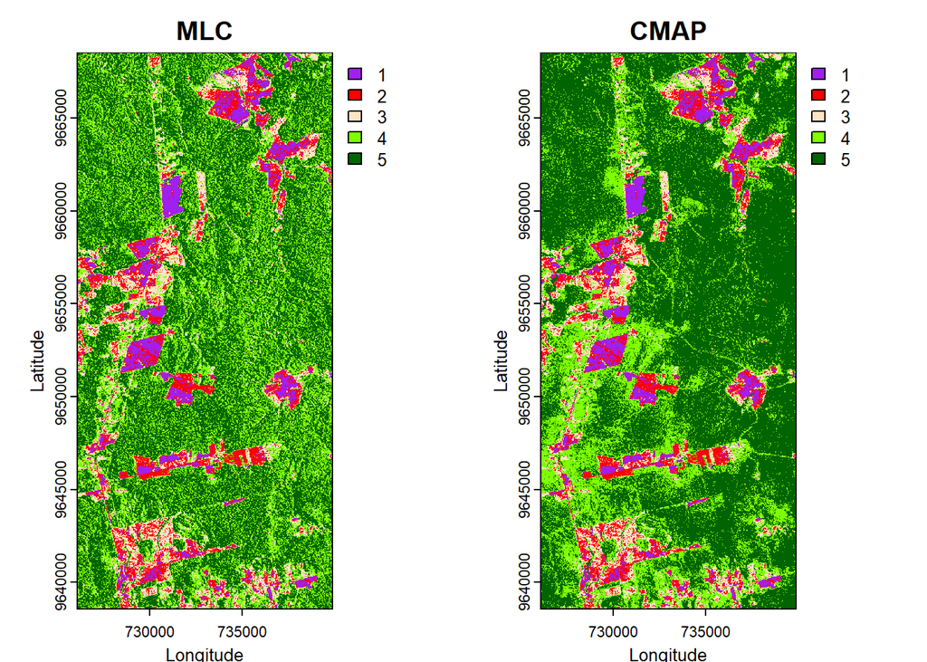